# Project - Pakistan Violent & Threatening Healthcare

In this project, we will be looking at two datasets that include information on violent and threatening incidents that impact aid operations, civilians, education, healthcare, refugees and IDPs in Pakistan. All of this is to make sure that the staff is safe and that hopefully there will be better response outcomes in the future. The link to have access to the two datasets is [here](https://www.kaggle.com/datasets/amaanfaheem/pakistan-violent-and-threatening-incidents#)

Some of the goals that we want to work with for the 2016-2022 dataset are the following:

1. **Which years have the most crime? Of the years that have the most crime, which year was worst?**
2. **Which weapon was used mostly? Of the most frequent weapon, which year was that frequent weapon used the most?**

For the 2019 dataset, we can focus on these goals:

1. **Which months were there the most crime? Of the months that had the most crime, which month was worse?**
2. **Which Provinces had the most crime?**

```python
# Importing the pandas library:
import pandas as pd
```

```python
# Importing the datetime library:
from datetime import datetime
```

```python
# Reading in the two datasets:
data_1 = pd.read_csv("C:/Users/salem/Downloads/2016-2022-pakistan-attacks-on-health-care-incident-data.csv")
data_2 = pd.read_csv("C:/Users/salem/Downloads/2019-shcc-healthcare-pakistan-data.csv")
```

```python
# Printing out the full 2016 - 2022 dataset:
data_1
```

|  | Date | Country | Country ISO | Reported Perpetrator | Reported Perpetrator Name | Weapon carried or used | Health Workers Killed | Health Workers Kidnapped | Health Workers Arrested | Health Workers Injured | ... | Health Transportation Damaged | Health Transportation Stolen/Highjacked | Looting/Theft/Robbery/Burglary of Health Supplies | Obstruction to health care | Conflict-Related Violence | Political-Related Violence | COVID-19-Related Violence | Ebola-Related Violence | Vaccination-Related Violence | SiND Event ID |
| --- | --- | --- | --- | --- | --- | --- | --- | --- | --- | --- | --- | --- | --- | --- | --- | --- | --- | --- | --- | --- | --- |
| 0 | #date | #country +name | #group +perp | #weapon | NaN | NaN | #affected +healthworker +killed | #affected +healthworker +kidnapped | #affected +healthworker +arrested | #affected +healthworker +injured | ... | #indicator +health_transport +damaged +num | #indicator +health_transport +abducted +num | #indicator +health_supplies +taken +num | #indicator +health_obstruction | NaN | NaN | NaN | NaN | NaN | NaN |
| 1 | 25/04/2019 | Pakistan | PAK | NSA | Unidentified armed actor | Firearms | 1 | 0 | 0 | 1 | ... | 0 | 0 | 0 | 0 | ConflictEvent | NotApplicable | NotApplicable | NotApplicable | NotApplicable | 23986.0 |
| 2 | 08/11/2019 | Pakistan | PAK | No Information | Unidentified armed actor | Firearms | 1 | 0 | 0 | 0 | ... | 0 | 0 | 0 | 0 | ConflictEvent | NotApplicable | NotApplicable | NotApplicable | NotApplicable | 34888.0 |
| 3 | 29/01/2020 | Pakistan | PAK | NSA | Unidentified armed actor | Firearms | 2 | 0 | 0 | 0 | ... | 0 | 0 | 0 | 0 | ConflictEvent | NotApplicable | NotApplicable | NotApplicable | NotApplicable | 24163.0 |
| 4 | 12/01/2021 | Pakistan | PAK | NSA | Unidentified armed actor | Firearms | 0 | 0 | 0 | 0 | ... | 0 | 0 | 0 | 0 | ConflictEvent | NotApplicable | NotApplicable | NotApplicable | NotApplicable | 26954.0 |
| 5 | 28/01/2021 | Pakistan | PAK | Employee | Employee | Not Applicable - no direct violence | 0 | 0 | 0 | 1 | ... | 0 | 0 | 0 | 0 | ConflictEvent | NotApplicable | NotApplicable | NotApplicable | NotApplicable | 27026.0 |
| 6 | 09/04/2021 | Pakistan | PAK | Police | Afghan National Police | Not Applicable - no direct violence | 0 | 0 | 2 | 0 | ... | 0 | 0 | 0 | 0 | ConflictEvent | NotApplicable | NotApplicable | NotApplicable | NotApplicable | 27782.0 |
| 7 | 09/06/2021 | Pakistan | PAK | NSA | Unidentified armed actor | Firearms | 0 | 0 | 0 | 0 | ... | 0 | 0 | 0 | 0 | ConflictEvent | NotApplicable | NotApplicable | NotApplicable | NotApplicable | 28493.0 |
| 8 | 30/09/2021 | Pakistan | PAK | NSA | Islamic State Khorasan Province (Afghanistan) | Firearms | 1 | 0 | 0 | 0 | ... | 0 | 0 | 0 | 0 | ConflictEvent | NotApplicable | NotApplicable | NotApplicable | NotApplicable | 29719.0 |
| 9 | 28/11/2021 | Pakistan | PAK | Police | Pakistan Police | Firearms | 0 | 0 | 19 | 0 | ... | 0 | 0 | 0 | 0 | ConflictEvent | NotApplicable | NotApplicable | NotApplicable | NotApplicable | 31876.0 |
| 10 | 11/12/2021 | Pakistan | PAK | NSA | TTP Tehrik-i-Taliban Pakistan | Firearms | 0 | 0 | 0 | 0 | ... | 0 | 0 | 0 | 0 | ConflictEvent | NotApplicable | NotApplicable | NotApplicable | NotApplicable | 30553.0 |
| 11 | 25/01/2022 | Pakistan | PAK | Criminal | Unidentified armed actor | Firearms | 0 | 0 | 0 | 0 | ... | 0 | 0 | 0 | 0 | ConflictEvent | NotApplicable | NotApplicable | NotApplicable | NotApplicable | 31204.0 |
| 12 | 18/05/2022 | Pakistan | PAK | NSA | Unidentified armed actor | No information on the weapon used | 0 | 0 | 1 | 0 | ... | 0 | 0 | 0 | 0 | ConflictEvent | NotApplicable | NotApplicable | NotApplicable | NotApplicable | 32921.0 |
| 13 | 28/06/2022 | Pakistan | PAK | Criminal | Unidentified armed actor | Firearms | 1 | 0 | 0 | 0 | ... | 0 | 0 | 0 | 0 | ConflictEvent | NotApplicable | NotApplicable | NotApplicable | NotApplicable | 33278.0 |
| 14 | 02/07/2022 | Pakistan | PAK | NSA | Unidentified armed actor | Firearms | 0 | 2 | 0 | 0 | ... | 0 | 0 | 0 | 0 | ConflictEvent | NotApplicable | NotApplicable | NotApplicable | NotApplicable | 33601.0 |
| 15 | 02/07/2022 | Pakistan | PAK | NSA | Unidentified armed actor | Firearms | 0 | 0 | 0 | 1 | ... | 0 | 0 | 0 | 0 | ConflictEvent | NotApplicable | NotApplicable | NotApplicable | NotApplicable | 33602.0 |
| 16 | 03/07/2022 | Pakistan | PAK | NSA | Unidentified armed actor | Firearms | 1 | 0 | 0 | 0 | ... | 0 | 0 | 0 | 0 | ConflictEvent | NotApplicable | NotApplicable | NotApplicable | NotApplicable | 33603.0 |
| 17 | 16/08/2022 | Pakistan | PAK | No Information | Unidentified armed actor | Firearms | 0 | 0 | 0 | 0 | ... | 0 | 0 | 0 | 0 | ConflictEvent | NotApplicable | NotApplicable | NotApplicable | NotApplicable | 34378.0 |

18 rows × 29 columns

```python
# Using frame.info() to look at information for the 2016-2022 DataFrame like their column names, column types, and number of missing values:
data_1.info()
```

```
<class 'pandas.core.frame.DataFrame'>
RangeIndex: 18 entries, 0 to 17
Data columns (total 29 columns):
 #   Column                                                        Non-Null Count  Dtype
---  ------                                                        --------------  -----
 0   Date                                                          18 non-null     object
 1   Country                                                       18 non-null     object
 2   Country ISO                                                   18 non-null     object
 3   Reported Perpetrator                                          18 non-null     object
 4   Reported Perpetrator Name                                     17 non-null     object
 5   Weapon carried or used                                        17 non-null     object
 6   Health Workers Killed                                         18 non-null     object
 7   Health Workers Kidnapped                                      18 non-null     object
 8   Health Workers Arrested                                       18 non-null     object
 9   Health Workers Injured                                        18 non-null     object
```

[output cut: 21 more lines]

```python
# Using the shape method to printing out how many rows and columns the 2016-2022 DataFrame has:
data_1.shape
```

```
(18, 29)
```

```python
# Selecting the columns from the 2016-2022 dataset that are relevant to our goals:
data_1 = data_1[["Date", "Reported Perpetrator", "Weapon carried or used", "Health Workers Killed", "Health Workers Kidnapped",
"Health Workers Arrested", "Health Workers Injured", "Health Workers Assaulted","Health Workers Sexually Assaulted"]]
```

```python
# Selected all of the rows below row number 0:
data_1 = data_1[1:]
```

```python
# Converting some of the column names from object to integer data type by using the Series astype method:
data_1["Health Workers Arrested"] = data_1["Health Workers Arrested"].astype('Int64')

data_1["Health Workers Assaulted"] = data_1["Health Workers Assaulted"].astype('Int64')

data_1["Health Workers Injured"] = data_1["Health Workers Injured"].astype('Int64')

data_1["Health Workers Kidnapped"] = data_1["Health Workers Kidnapped"].astype('Int64')

data_1["Health Workers Killed"] = data_1["Health Workers Killed"].astype('Int64')

data_1["Health Workers Arrested"] = data_1["Health Workers Arrested"].astype('Int64')

data_1["Health Workers Sexually Assaulted"] = data_1["Health Workers Sexually Assaulted"].astype('Int64')
```

```python
# Converting the 'Date' column to datetime with the pandas.to_datetime method:
data_1['Date'] = pd.to_datetime(data_1['Date'])
```

```python
# Using frame.info() again to see the updated information of the dataset:
data_1.info()
```

```
<class 'pandas.core.frame.DataFrame'>
RangeIndex: 17 entries, 1 to 17
Data columns (total 9 columns):
 #   Column                             Non-Null Count  Dtype
---  ------                             --------------  -----
 0   Date                               17 non-null     datetime64[ns]
 1   Reported Perpetrator               17 non-null     object
 2   Weapon carried or used             17 non-null     object
 3   Health Workers Killed              17 non-null     Int64
 4   Health Workers Kidnapped           17 non-null     Int64
 5   Health Workers Arrested            17 non-null     Int64
 6   Health Workers Injured             17 non-null     Int64
 7   Health Workers Assaulted           17 non-null     Int64
 8   Health Workers Sexually Assaulted  17 non-null     Int64
dtypes: Int64(6), datetime64[ns](1), object(2)
memory usage: 1.4+ KB
```

```python
# Printing out the fully updated DataFrame:
data_1
```

|  | Date | Reported Perpetrator | Weapon carried or used | Health Workers Killed | Health Workers Kidnapped | Health Workers Arrested | Health Workers Injured | Health Workers Assaulted | Health Workers Sexually Assaulted |
| --- | --- | --- | --- | --- | --- | --- | --- | --- | --- |
| 1 | 2019-04-25 | NSA | Firearms | 1 | 0 | 0 | 1 | 0 | 0 |
| 2 | 2019-11-08 | No Information | Firearms | 1 | 0 | 0 | 0 | 0 | 0 |
| 3 | 2020-01-29 | NSA | Firearms | 2 | 0 | 0 | 0 | 0 | 0 |
| 4 | 2021-01-12 | NSA | Firearms | 0 | 0 | 0 | 0 | 0 | 0 |
| 5 | 2021-01-28 | Employee | Not Applicable - no direct violence | 0 | 0 | 0 | 1 | 1 | 0 |
| 6 | 2021-04-09 | Police | Not Applicable - no direct violence | 0 | 0 | 2 | 0 | 0 | 0 |
| 7 | 2021-06-09 | NSA | Firearms | 0 | 0 | 0 | 0 | 0 | 0 |
| 8 | 2021-09-30 | NSA | Firearms | 1 | 0 | 0 | 0 | 0 | 0 |
| 9 | 2021-11-28 | Police | Firearms | 0 | 0 | 19 | 0 | 0 | 0 |
| 10 | 2021-12-11 | NSA | Firearms | 0 | 0 | 0 | 0 | 0 | 0 |
| 11 | 2022-01-25 | Criminal | Firearms | 0 | 0 | 0 | 0 | 0 | 0 |
| 12 | 2022-05-18 | NSA | No information on the weapon used | 0 | 0 | 1 | 0 | 0 | 0 |
| 13 | 2022-06-28 | Criminal | Firearms | 1 | 0 | 0 | 0 | 0 | 0 |
| 14 | 2022-07-02 | NSA | Firearms | 0 | 2 | 0 | 0 | 0 | 0 |
| 15 | 2022-07-02 | NSA | Firearms | 0 | 0 | 0 | 1 | 0 | 0 |
| 16 | 2022-07-03 | NSA | Firearms | 1 | 0 | 0 | 0 | 0 | 0 |
| 17 | 2022-08-16 | No Information | Firearms | 0 | 0 | 0 | 0 | 0 | 0 |

```python
# Using the isna method to print out a Boolean Series where if values are null, True will be printed, otherwise, False will be printed:
data_1.isna()
```

|  | Date | Reported Perpetrator | Weapon carried or used | Health Workers Killed | Health Workers Kidnapped | Health Workers Arrested | Health Workers Injured | Health Workers Assaulted | Health Workers Sexually Assaulted |
| --- | --- | --- | --- | --- | --- | --- | --- | --- | --- |
| 1 | False | False | False | False | False | False | False | False | False |
| 2 | False | False | False | False | False | False | False | False | False |
| 3 | False | False | False | False | False | False | False | False | False |
| 4 | False | False | False | False | False | False | False | False | False |
| 5 | False | False | False | False | False | False | False | False | False |
| 6 | False | False | False | False | False | False | False | False | False |
| 7 | False | False | False | False | False | False | False | False | False |
| 8 | False | False | False | False | False | False | False | False | False |
| 9 | False | False | False | False | False | False | False | False | False |
| 10 | False | False | False | False | False | False | False | False | False |
| 11 | False | False | False | False | False | False | False | False | False |
| 12 | False | False | False | False | False | False | False | False | False |
| 13 | False | False | False | False | False | False | False | False | False |
| 14 | False | False | False | False | False | False | False | False | False |
| 15 | False | False | False | False | False | False | False | False | False |
| 16 | False | False | False | False | False | False | False | False | False |
| 17 | False | False | False | False | False | False | False | False | False |

```python
# Printing out the first couple of rows for the 2016-2022 DataFrame:
data_1.head()
```

|  | Date | Reported Perpetrator | Weapon carried or used | Health Workers Killed | Health Workers Kidnapped | Health Workers Arrested | Health Workers Injured | Health Workers Assaulted | Health Workers Sexually Assaulted |
| --- | --- | --- | --- | --- | --- | --- | --- | --- | --- |
| 1 | 2019-04-25 | NSA | Firearms | 1 | 0 | 0 | 1 | 0 | 0 |
| 2 | 2019-11-08 | No Information | Firearms | 1 | 0 | 0 | 0 | 0 | 0 |
| 3 | 2020-01-29 | NSA | Firearms | 2 | 0 | 0 | 0 | 0 | 0 |
| 4 | 2021-01-12 | NSA | Firearms | 0 | 0 | 0 | 0 | 0 | 0 |
| 5 | 2021-01-28 | Employee | Not Applicable - no direct violence | 0 | 0 | 0 | 1 | 1 | 0 |

```python
# Printing out whole 2019 DataFrame:
data_2
```

|  | SHCC Event Code | Country | State/Province/Division/Governorate/Department | Incident date | Incident year | Incident month | Incident day | SHCC Attack Type | SHCC Attack Context | Total health worker killed | ... | Total health worker assaulted | Total health worker sexual violence | Total number of attacks on facilities which reported destruction | Total number of attacks on facilities which reported damage | Armed entry into medical facilities | Looting, theft, robbery, burglary of health supplies | Health transportation destroyed | Health transportation damaged | Health transportation stolen/highjacked | Perpetrator |
| --- | --- | --- | --- | --- | --- | --- | --- | --- | --- | --- | --- | --- | --- | --- | --- | --- | --- | --- | --- | --- | --- |
| 0 | #event +id | #country +name | #country +name +loc | #date +occurrence | NaN | NaN | NaN | #event +type | #event +context | #affected +healthworker +killed | ... | #affected +healthworker +assaulted | #affected +healthworker +SGBV | #indicator +health_facility +destroyed +num | #indicator +health_facility +damaged +num | #indicator +health_facility +armed_entry +num | #indicator +health_supplies +taken +num | #indicator +health_transport +destroyed +num | #indicator +health_transport +damaged +num | #indicator +health_transport +abducted +num | #group +perp +name |
| 1 | PAK1 | Pakistan | Balochistan province | 2019-04 | 2019.0 | April | 25.0 | Intentional | Health programmes | 1 | ... | NaN | NaN | NaN | NaN | NaN | NaN | NaN | NaN | NaN | UnspecNonMilArmed |
| 2 | PAK2 | Pakistan | Khyber Pakhtunkhwa province | 2019-04 | 2019.0 | April | 8.0 | Intentional | Health programmes | 1 | ... | NaN | NaN | NaN | NaN | NaN | NaN | NaN | NaN | NaN | NoInformation |
| 3 | PAK3 | Pakistan | Punjab province | 2019-04 | 2019.0 | April | 28.0 | Intentional | Individuals | 1 | ... | NaN | NaN | NaN | NaN | NaN | NaN | NaN | NaN | NaN | UnspecNonMilArmed |
| 4 | PAK4 | Pakistan | Punjab province | 2019-04 | 2019.0 | April | 23.0 | Intentional | Health programmes | 1 | ... | NaN | NaN | NaN | NaN | NaN | NaN | NaN | NaN | NaN | UnspecNonMilArmed |
| 5 | PAK5 | Pakistan | Khyber Pakhtunkhwa province | 2019-04 | 2019.0 | April | 22.0 | Intentional | Health programmes | NaN | ... | NaN | NaN | NaN | 1 | 1 | NaN | NaN | NaN | NaN | UnspecNonMilArmed |
| 6 | PAK6 | Pakistan | Sindh province | 2019-08 | 2019.0 | August | 30.0 | Intentional | Individuals | 1 | ... | NaN | NaN | NaN | NaN | NaN | NaN | NaN | NaN | NaN | UnspecNonMilArmed |
| 7 | PAK7 | Pakistan | Khyber Pakhtunkhwa province | 2019-07 | 2019.0 | July | 21.0 | Intentional | Health programmes | NaN | ... | NaN | NaN | NaN | 1 | NaN | NaN | NaN | NaN | NaN | NonStateArmedGroups |
| 8 | PAK8 | Pakistan | Khyber Pakhtunkhwa province | 2019-07 | 2019.0 | July | 28.0 | Intentional | Individuals | NaN | ... | NaN | NaN | NaN | NaN | NaN | NaN | NaN | NaN | NaN | NoInformation |
| 9 | PAK9 | Pakistan | Khyber Pakhtunkhwa province | 2019-09 | 2019.0 | September | 11.0 | Intentional | Individuals | NaN | ... | NaN | NaN | NaN | NaN | NaN | NaN | NaN | NaN | NaN | UnspecNonMilArmed |
| 10 | PAK10 | Pakistan | Khyber Pakhtunkhwa province | 2019-09 | 2019.0 | September | 16.0 | Intentional | Individuals | NaN | ... | NaN | NaN | NaN | NaN | NaN | NaN | NaN | NaN | NaN | UnspecNonMilArmed |
| 11 | PAK11 | Pakistan | Khyber Pakhtunkhwa province | 2019-12 | 2019.0 | December | 9.0 | Intentional | Health programmes | 1 | ... | NaN | NaN | NaN | NaN | NaN | NaN | NaN | NaN | NaN | UnspecNonMilArmed |
| 12 | PAK12 | Pakistan | Khyber Pakhtunkhwa province | 2019-12 | 2019.0 | December | 18.0 | Intentional | Health programmes | NaN | ... | NaN | NaN | NaN | NaN | NaN | NaN | NaN | NaN | NaN | UnspecNonMilArmed |
| 13 | PAK13 | Pakistan | Khyber Pakhtunkhwa province | 2019-02 | 2019.0 | February | 5.0 | Intentional | Looting and common crime | 1 | ... | NaN | NaN | NaN | NaN | NaN | NaN | NaN | NaN | NaN | UnspecNonMilArmed |
| 14 | PAK14 | Pakistan | Balochistan province | 2019-07 | 2019.0 | July | 13.0 | Intentional | Individuals | 1 | ... | NaN | NaN | NaN | NaN | NaN | NaN | NaN | NaN | NaN | UnspecNonMilArmed |
| 15 | PAK15 | Pakistan | Khyber Pakhtunkhwa province | 2019-03 | 2019.0 | March | 25.0 | Intentional | Health programmes | NaN | ... | NaN | NaN | NaN | NaN | NaN | NaN | NaN | NaN | NaN | CommunityMembers |
| 16 | PAK16 | Pakistan | Punjab province | 2019-03 | 2019.0 | March | 9.0 | NoInformation | Individuals | NaN | ... | NaN | NaN | NaN | NaN | NaN | NaN | NaN | NaN | NaN | UnspecNonMilArmed |
| 17 | PAK17 | Pakistan | Punjab province | 2019-03 | 2019.0 | March | 13.0 | Intentional | Individuals | NaN | ... | NaN | NaN | NaN | NaN | NaN | NaN | NaN | NaN | NaN | NoInformation |
| 18 | PAK18 | Pakistan | Punjab province | 2019-03 | 2019.0 | March | 20.0 | Intentional | Individuals | NaN | ... | NaN | NaN | NaN | NaN | NaN | NaN | NaN | NaN | NaN | NoInformation |
| 19 | PAK19 | Pakistan | Khyber Pakhtunkhwa province | 2019-03 | 2019.0 | March | 13.0 | NoInformation | Individuals | 1 | ... | NaN | NaN | NaN | NaN | NaN | NaN | NaN | NaN | NaN | NoInformation |
| 20 | PAK20 | Pakistan | Khyber Pakhtunkhwa province | 2019-05 | 2019.0 | May | 4.0 | Intentional | Health programmes | 1 | ... | NaN | NaN | NaN | NaN | NaN | NaN | NaN | NaN | NaN | NoInformation |
| 21 | PAK21 | Pakistan | Punjab province | 2019-05 | 2019.0 | May | 4.0 | NoInformation | Individuals | NaN | ... | NaN | NaN | NaN | NaN | NaN | NaN | NaN | NaN | NaN | UnspecNonMilArmed |
| 22 | PAK22 | Pakistan | Punjab province | 2019-11 | 2019.0 | November | 8.0 | Intentional | Individuals | 1 | ... | NaN | NaN | NaN | NaN | NaN | NaN | NaN | NaN | NaN | NoInformation |
| 23 | PAK23 | Pakistan | Khyber Pakhtunkhwa province | 2019-09 | 2019.0 | September | 6.0 | Intentional | Health programmes | 1 | ... | NaN | NaN | NaN | NaN | NaN | NaN | NaN | NaN | NaN | UnspecNonMilArmed |

24 rows × 25 columns

```python
# Using frame.info() to look at information for the 2019 DataFrame like their column names, column types, and number of missing values:
data_2.info()
```

```
<class 'pandas.core.frame.DataFrame'>
RangeIndex: 24 entries, 0 to 23
Data columns (total 25 columns):
 #   Column                                                            Non-Null Count  Dtype
---  ------                                                            --------------  -----
 0   SHCC Event Code                                                   24 non-null     object
 1   Country                                                           24 non-null     object
 2   State/Province/Division/Governorate/Department                    24 non-null     object
 3   Incident date                                                     24 non-null     object
 4   Incident year                                                     23 non-null     float64
 5   Incident month                                                    23 non-null     object
 6   Incident day                                                      23 non-null     float64
 7   SHCC Attack Type                                                  24 non-null     object
 8   SHCC Attack Context                                               24 non-null     object
 9   Total health worker killed                                        13 non-null     object
```

[output cut: 17 more lines]

```python
# Selecting the columns from the 2019 dataset that are relevant to our goals:
data_2 = data_2[["Incident month", "State/Province/Division/Governorate/Department", "Total health worker killed", "Total health worker kidnapped",
                 "Total health worker injured"]]
```

```python
# Selected all of the rows below row number 0:
data_2 = data_2[1:]
```

```python
# Converting some of the column names from object to integer data type by using the Series astype method:
data_2["Total health worker killed"] = data_2["Total health worker injured"].astype('Int64')

data_2["Total health worker kidnapped"] = data_2["Total health worker kidnapped"].astype('Int64')

data_2["Total health worker injured"] = data_2["Total health worker injured"].astype('Int64')
```

```python
# Using the isna method to print out a Boolean Series where if values are null, True will be printed, otherwise, False will be printed:
data_2.isna()
```

|  | Incident month | State/Province/Division/Governorate/Department | Total health worker killed | Total health worker kidnapped | Total health worker injured |
| --- | --- | --- | --- | --- | --- |
| 1 | False | False | False | True | False |
| 2 | False | False | True | True | True |
| 3 | False | False | True | True | True |
| 4 | False | False | True | True | True |
| 5 | False | False | True | True | True |
| 6 | False | False | True | True | True |
| 7 | False | False | True | True | True |
| 8 | False | False | False | True | False |
| 9 | False | False | True | False | True |
| 10 | False | False | True | False | True |
| 11 | False | False | True | True | True |
| 12 | False | False | True | True | True |
| 13 | False | False | True | True | True |
| 14 | False | False | True | True | True |
| 15 | False | False | False | True | False |
| 16 | False | False | False | True | False |
| 17 | False | False | True | False | True |
| 18 | False | False | False | True | False |
| 19 | False | False | True | True | True |
| 20 | False | False | True | True | True |
| 21 | False | False | False | True | False |
| 22 | False | False | True | True | True |
| 23 | False | False | True | True | True |

```python
data_2
```

|  | Incident month | State/Province/Division/Governorate/Department | Total health worker killed | Total health worker kidnapped | Total health worker injured |
| --- | --- | --- | --- | --- | --- |
| 1 | April | Balochistan province | 1 | <NA> | 1 |
| 2 | April | Khyber Pakhtunkhwa province | <NA> | <NA> | <NA> |
| 3 | April | Punjab province | <NA> | <NA> | <NA> |
| 4 | April | Punjab province | <NA> | <NA> | <NA> |
| 5 | April | Khyber Pakhtunkhwa province | <NA> | <NA> | <NA> |
| 6 | August | Sindh province | <NA> | <NA> | <NA> |
| 7 | July | Khyber Pakhtunkhwa province | <NA> | <NA> | <NA> |
| 8 | July | Khyber Pakhtunkhwa province | 2 | <NA> | 2 |
| 9 | September | Khyber Pakhtunkhwa province | <NA> | 1 | <NA> |
| 10 | September | Khyber Pakhtunkhwa province | <NA> | 1 | <NA> |
| 11 | December | Khyber Pakhtunkhwa province | <NA> | <NA> | <NA> |
| 12 | December | Khyber Pakhtunkhwa province | <NA> | <NA> | <NA> |
| 13 | February | Khyber Pakhtunkhwa province | <NA> | <NA> | <NA> |
| 14 | July | Balochistan province | <NA> | <NA> | <NA> |
| 15 | March | Khyber Pakhtunkhwa province | 1 | <NA> | 1 |
| 16 | March | Punjab province | 1 | <NA> | 1 |
| 17 | March | Punjab province | <NA> | 2 | <NA> |
| 18 | March | Punjab province | 1 | <NA> | 1 |
| 19 | March | Khyber Pakhtunkhwa province | <NA> | <NA> | <NA> |
| 20 | May | Khyber Pakhtunkhwa province | <NA> | <NA> | <NA> |
| 21 | May | Punjab province | 1 | <NA> | 1 |
| 22 | November | Punjab province | <NA> | <NA> | <NA> |
| 23 | September | Khyber Pakhtunkhwa province | <NA> | <NA> | <NA> |

```python
# Using the fillna method to replace the NA values with 0:
data_2 = data_2.fillna(0)
```

```python
data_2
```

|  | Incident month | State/Province/Division/Governorate/Department | Total health worker killed | Total health worker kidnapped | Total health worker injured |
| --- | --- | --- | --- | --- | --- |
| 1 | April | Balochistan province | 1 | 0 | 1 |
| 2 | April | Khyber Pakhtunkhwa province | 0 | 0 | 0 |
| 3 | April | Punjab province | 0 | 0 | 0 |
| 4 | April | Punjab province | 0 | 0 | 0 |
| 5 | April | Khyber Pakhtunkhwa province | 0 | 0 | 0 |
| 6 | August | Sindh province | 0 | 0 | 0 |
| 7 | July | Khyber Pakhtunkhwa province | 0 | 0 | 0 |
| 8 | July | Khyber Pakhtunkhwa province | 2 | 0 | 2 |
| 9 | September | Khyber Pakhtunkhwa province | 0 | 1 | 0 |
| 10 | September | Khyber Pakhtunkhwa province | 0 | 1 | 0 |
| 11 | December | Khyber Pakhtunkhwa province | 0 | 0 | 0 |
| 12 | December | Khyber Pakhtunkhwa province | 0 | 0 | 0 |
| 13 | February | Khyber Pakhtunkhwa province | 0 | 0 | 0 |
| 14 | July | Balochistan province | 0 | 0 | 0 |
| 15 | March | Khyber Pakhtunkhwa province | 1 | 0 | 1 |
| 16 | March | Punjab province | 1 | 0 | 1 |
| 17 | March | Punjab province | 0 | 2 | 0 |
| 18 | March | Punjab province | 1 | 0 | 1 |
| 19 | March | Khyber Pakhtunkhwa province | 0 | 0 | 0 |
| 20 | May | Khyber Pakhtunkhwa province | 0 | 0 | 0 |
| 21 | May | Punjab province | 1 | 0 | 1 |
| 22 | November | Punjab province | 0 | 0 | 0 |
| 23 | September | Khyber Pakhtunkhwa province | 0 | 0 | 0 |

```python
# Printing out the first five rows of the 2019 dataframe:
data_2.head()
```

|  | Incident month | State/Province/Division/Governorate/Department | Total health worker killed | Total health worker kidnapped | Total health worker injured |
| --- | --- | --- | --- | --- | --- |
| 1 | April | Balochistan province | 1 | 0 | 1 |
| 2 | April | Khyber Pakhtunkhwa province | 0 | 0 | 0 |
| 3 | April | Punjab province | 0 | 0 | 0 |
| 4 | April | Punjab province | 0 | 0 | 0 |
| 5 | April | Khyber Pakhtunkhwa province | 0 | 0 | 0 |

```python
# Extracting the day, month, and year components from the Date column:
data_1['year'] = data_1['Date'].dt.year
data_1['month'] = data_1['Date'].dt.month
data_1['day'] = data_1['Date'].dt.day
```

```python
# Printing the modified 2016-2022 DataFrame:
data_1
```

|  | Date | Reported Perpetrator | Weapon carried or used | Health Workers Killed | Health Workers Kidnapped | Health Workers Arrested | Health Workers Injured | Health Workers Assaulted | Health Workers Sexually Assaulted | year | month | day |
| --- | --- | --- | --- | --- | --- | --- | --- | --- | --- | --- | --- | --- |
| 1 | 2019-04-25 | NSA | Firearms | 1 | 0 | 0 | 1 | 0 | 0 | 2019 | 4 | 25 |
| 2 | 2019-11-08 | No Information | Firearms | 1 | 0 | 0 | 0 | 0 | 0 | 2019 | 11 | 8 |
| 3 | 2020-01-29 | NSA | Firearms | 2 | 0 | 0 | 0 | 0 | 0 | 2020 | 1 | 29 |
| 4 | 2021-01-12 | NSA | Firearms | 0 | 0 | 0 | 0 | 0 | 0 | 2021 | 1 | 12 |
| 5 | 2021-01-28 | Employee | Not Applicable - no direct violence | 0 | 0 | 0 | 1 | 1 | 0 | 2021 | 1 | 28 |
| 6 | 2021-04-09 | Police | Not Applicable - no direct violence | 0 | 0 | 2 | 0 | 0 | 0 | 2021 | 4 | 9 |
| 7 | 2021-06-09 | NSA | Firearms | 0 | 0 | 0 | 0 | 0 | 0 | 2021 | 6 | 9 |
| 8 | 2021-09-30 | NSA | Firearms | 1 | 0 | 0 | 0 | 0 | 0 | 2021 | 9 | 30 |
| 9 | 2021-11-28 | Police | Firearms | 0 | 0 | 19 | 0 | 0 | 0 | 2021 | 11 | 28 |
| 10 | 2021-12-11 | NSA | Firearms | 0 | 0 | 0 | 0 | 0 | 0 | 2021 | 12 | 11 |
| 11 | 2022-01-25 | Criminal | Firearms | 0 | 0 | 0 | 0 | 0 | 0 | 2022 | 1 | 25 |
| 12 | 2022-05-18 | NSA | No information on the weapon used | 0 | 0 | 1 | 0 | 0 | 0 | 2022 | 5 | 18 |
| 13 | 2022-06-28 | Criminal | Firearms | 1 | 0 | 0 | 0 | 0 | 0 | 2022 | 6 | 28 |
| 14 | 2022-07-02 | NSA | Firearms | 0 | 2 | 0 | 0 | 0 | 0 | 2022 | 7 | 2 |
| 15 | 2022-07-02 | NSA | Firearms | 0 | 0 | 0 | 1 | 0 | 0 | 2022 | 7 | 2 |
| 16 | 2022-07-03 | NSA | Firearms | 1 | 0 | 0 | 0 | 0 | 0 | 2022 | 7 | 3 |
| 17 | 2022-08-16 | No Information | Firearms | 0 | 0 | 0 | 0 | 0 | 0 | 2022 | 8 | 16 |

```python
# Using the value_counts method to count up how often each year in the year column appears in the 2016-2022 DataFrame:
year_counts = data_1['year'].value_counts().sort_index()
```

```python
# Printing out the frequency table of the the frequency of the years:
year_counts
```

```
year
2019    2
2020    1
2021    7
2022    7
Name: count, dtype: int64
```

```python
# Importing the seaborn package:
import seaborn as sns
```

```python
# Importing the matplotlib library:
import matplotlib.pyplot as plt
```

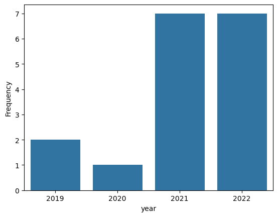

```python
# Making a bar plot for the short frequency table of the years:
sns.barplot(x=year_counts.index, y=year_counts.to_numpy())
plt.ylabel('Frequency')
```

- Based off the bar plot above, it is safe to say that the years where the most crime happened would be 2021 and 2022. We can go one step further and do more analysis on 2021 and 2022.

```python
# Having two separate DataFrames for 2021 and 2022:
data_2021 = data_1[data_1['year'] == 2021]
data_2022 = data_1[data_1['year'] == 2022]
```

```python
data_2021
```

|  | Date | Reported Perpetrator | Weapon carried or used | Health Workers Killed | Health Workers Kidnapped | Health Workers Arrested | Health Workers Injured | Health Workers Assaulted | Health Workers Sexually Assaulted | year | month | day |
| --- | --- | --- | --- | --- | --- | --- | --- | --- | --- | --- | --- | --- |
| 4 | 2021-01-12 | NSA | Firearms | 0 | 0 | 0 | 0 | 0 | 0 | 2021 | 1 | 12 |
| 5 | 2021-01-28 | Employee | Not Applicable - no direct violence | 0 | 0 | 0 | 1 | 1 | 0 | 2021 | 1 | 28 |
| 6 | 2021-04-09 | Police | Not Applicable - no direct violence | 0 | 0 | 2 | 0 | 0 | 0 | 2021 | 4 | 9 |
| 7 | 2021-06-09 | NSA | Firearms | 0 | 0 | 0 | 0 | 0 | 0 | 2021 | 6 | 9 |
| 8 | 2021-09-30 | NSA | Firearms | 1 | 0 | 0 | 0 | 0 | 0 | 2021 | 9 | 30 |
| 9 | 2021-11-28 | Police | Firearms | 0 | 0 | 19 | 0 | 0 | 0 | 2021 | 11 | 28 |
| 10 | 2021-12-11 | NSA | Firearms | 0 | 0 | 0 | 0 | 0 | 0 | 2021 | 12 | 11 |

```python
# Using the sum method to return the sum of Health Workers Injured in 2021:
Injured_2021 = data_2021['Health Workers Injured'].sum()
```

```python
# Using the sum method to return the sum of Health Workers Killed in 2021:
Killed_2021 = data_2021['Health Workers Killed'].sum()
```

```python
# Using the sum method to return the sum of Health Workers Arrested in 2021:
Arrested_2021 = data_2021['Health Workers Arrested'].sum()
```

```python
# Using the sum method to return the sum of Health Workers kidnapped in 2021:
Kidnapped_2021 = data_2021['Health Workers Kidnapped'].sum()
```

```python
# Using the sum method to return the sum of Health Workers Assaulted in 2021:
Assaulted_2021 = data_2021['Health Workers Assaulted'].sum()
```

```python
# Using the sum method to return the sum of Health Workers sexually assaulted in 2021:
Sexual_Assaulted_2021 = data_2021['Health Workers Sexually Assaulted'].sum()
```

```python
# Using the sum method to return the sum of Health Workers Killed in 2022:
Killed_2022 = data_2022['Health Workers Killed'].sum()
```

```python
# Using the sum method to return the sum of Health Workers kidnapped in 2022:
Kidnapped_2022 = data_2022['Health Workers Kidnapped'].sum()
```

```python
# Using the sum method to return the sum of Health Workers Arrested in 2022:
Arrested_2022 = data_2022['Health Workers Arrested'].sum()
```

```python
# Using the sum method to return the sum of Health Workers injured in 2022:
Injured_2022 = data_2022['Health Workers Injured'].sum()
```

```python
# Using the sum method to return the sum of Health Workers assaulted in 2022:
Assaulted_2022 = data_2022['Health Workers Assaulted'].sum()
```

```python
# Using the sum method to return the sum of Health Workers sexually assaulted in 2022:
Sexual_Assaulted_2022 = data_2022['Health Workers Sexually Assaulted'].sum()
```

```python
# Using a dictionary to create a DataFrame:
data = {
        "Arrests": [Arrested_2021, Arrested_2022],
        "Kidnappings": [Kidnapped_2021, Kidnapped_2022],
        "Assaults": [Assaulted_2021, Assaulted_2022],
        "Sexual Assaults": [Sexual_Assaulted_2021, Sexual_Assaulted_2022],
        "Killings": [Killed_2021, Killed_2022],
        "Injuries": [Injured_2021, Injured_2022]
       }
```

```python
# Creating a dataframe for 2021 and 2022:
data = pd.DataFrame(data, index = [2021, 2022])
```

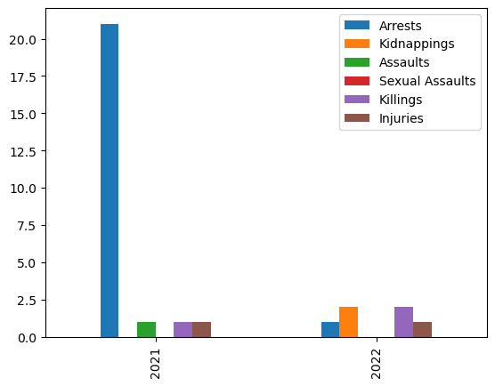

```python
# Creating a bar plot for all of the different incidents for years 2021 and 2022:
data.plot.bar()
```

- Based off of the bar plot above, it is safe to say that 2021 was worse than 2022 because there were more arrests and assaults. However, there were more kidnappings and killings in 2022 than there were in 2021.

```python
# Using the value_counts method to count up how frequent each weapon showed up in the weapon column appears in the 2016-2022 DataFrame:
weapon_counts = data_1['Weapon carried or used'].value_counts()
```

```python
# Printing out the frequency table for the weapons column:
weapon_counts
```

```
Weapon carried or used
Firearms                               14
Not Applicable - no direct violence     2
No information on the weapon used       1
Name: count, dtype: int64
```

```
([0, 1, 2],
 [Text(0, 0, 'Firearms'),
```

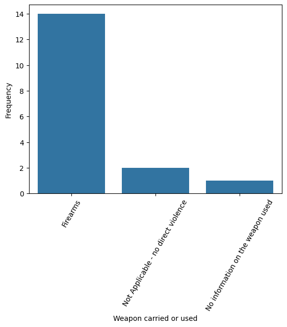

```python
# Making a bar plot for the short frequency table of the weapons column:
sns.barplot(x=weapon_counts.index, y=weapon_counts.to_numpy())
plt.ylabel('Frequency')
plt.xticks(rotation = 60)
```

- Based off the bar plot above, we can say that the weapon that was used mostly were Firearms. We can also with this go one step further and filter our DataFrame to only include the rows where the weapon involved was a firearm

```python
# Filtering our DataFrame so that we include rows that include a weapon of a firearm:
firearms = data_1[data_1['Weapon carried or used'] == 'Firearms']
```

```python
firearms
```

|  | Date | Reported Perpetrator | Weapon carried or used | Health Workers Killed | Health Workers Kidnapped | Health Workers Arrested | Health Workers Injured | Health Workers Assaulted | Health Workers Sexually Assaulted | year | month | day |
| --- | --- | --- | --- | --- | --- | --- | --- | --- | --- | --- | --- | --- |
| 1 | 2019-04-25 | NSA | Firearms | 1 | 0 | 0 | 1 | 0 | 0 | 2019 | 4 | 25 |
| 2 | 2019-11-08 | No Information | Firearms | 1 | 0 | 0 | 0 | 0 | 0 | 2019 | 11 | 8 |
| 3 | 2020-01-29 | NSA | Firearms | 2 | 0 | 0 | 0 | 0 | 0 | 2020 | 1 | 29 |
| 4 | 2021-01-12 | NSA | Firearms | 0 | 0 | 0 | 0 | 0 | 0 | 2021 | 1 | 12 |
| 7 | 2021-06-09 | NSA | Firearms | 0 | 0 | 0 | 0 | 0 | 0 | 2021 | 6 | 9 |
| 8 | 2021-09-30 | NSA | Firearms | 1 | 0 | 0 | 0 | 0 | 0 | 2021 | 9 | 30 |
| 9 | 2021-11-28 | Police | Firearms | 0 | 0 | 19 | 0 | 0 | 0 | 2021 | 11 | 28 |
| 10 | 2021-12-11 | NSA | Firearms | 0 | 0 | 0 | 0 | 0 | 0 | 2021 | 12 | 11 |
| 11 | 2022-01-25 | Criminal | Firearms | 0 | 0 | 0 | 0 | 0 | 0 | 2022 | 1 | 25 |
| 13 | 2022-06-28 | Criminal | Firearms | 1 | 0 | 0 | 0 | 0 | 0 | 2022 | 6 | 28 |
| 14 | 2022-07-02 | NSA | Firearms | 0 | 2 | 0 | 0 | 0 | 0 | 2022 | 7 | 2 |
| 15 | 2022-07-02 | NSA | Firearms | 0 | 0 | 0 | 1 | 0 | 0 | 2022 | 7 | 2 |
| 16 | 2022-07-03 | NSA | Firearms | 1 | 0 | 0 | 0 | 0 | 0 | 2022 | 7 | 3 |
| 17 | 2022-08-16 | No Information | Firearms | 0 | 0 | 0 | 0 | 0 | 0 | 2022 | 8 | 16 |

```python
# Using the value_counts method to count up how often a firearm appeared for each of the years in the 2016-2022 DataFrame:
firearms_year_counts = firearms['year'].value_counts().sort_index()
```

```python
firearms_year_counts
```

```
year
2019    2
2020    1
2021    5
2022    6
Name: count, dtype: int64
```

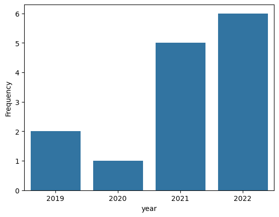

```python
# Making a bar plot for the short frequency table of the years:
sns.barplot(x=firearms_year_counts.index, y=firearms_year_counts.to_numpy())
plt.ylabel('Frequency')
```

- Based off the bar graph above, a firearm was mostly used in 2022.

```python
# Printing out the first five rows of the 2019 dataframe:
data_2.head()
```

|  | Incident month | State/Province/Division/Governorate/Department | Total health worker killed | Total health worker kidnapped | Total health worker injured |
| --- | --- | --- | --- | --- | --- |
| 1 | April | Balochistan province | 1 | 0 | 1 |
| 2 | April | Khyber Pakhtunkhwa province | 0 | 0 | 0 |
| 3 | April | Punjab province | 0 | 0 | 0 |
| 4 | April | Punjab province | 0 | 0 | 0 |
| 5 | April | Khyber Pakhtunkhwa province | 0 | 0 | 0 |

```python
# Making the month column a datetime data type so that we can sort it and using %B because the data uses the full month name:
data_2["Incident month"] = pd.to_datetime(data_2["Incident month"], format = "%B").dt.month

# Sorting the Data Frame by the Incident Month column:
data_2 = data_2.sort_values(by="Incident month")
```

```python
# Using the value_counts method to count up how often each month in the month column appears in the 2019 DataFrame:
month_counts = data_2['Incident month'].value_counts().sort_index()
```

```python
# Printing out the small frequency table of months:
month_counts
```

```
Incident month
2     1
3     5
4     5
5     2
7     3
8     1
9     3
11    1
12    2
Name: count, dtype: int64
```

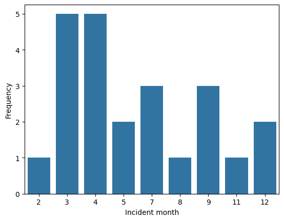

```python
# Making a bar plot for the short frequency table of the months:
sns.barplot(x=month_counts.index, y=month_counts.to_numpy())
plt.ylabel('Frequency')
```

- Based off the bar plot above, we can see that most of the crimes happened in the months of March and April.

```python
# Having two separate DataFrames for March and April:
march_2019 = data_2[data_2['Incident month'] == 3]
april_2019 = data_2[data_2['Incident month'] == 4]
```

```python
march_2019
```

|  | Incident month | State/Province/Division/Governorate/Department | Total health worker killed | Total health worker kidnapped | Total health worker injured |
| --- | --- | --- | --- | --- | --- |
| 17 | 3 | Punjab province | 0 | 2 | 0 |
| 15 | 3 | Khyber Pakhtunkhwa province | 1 | 0 | 1 |
| 18 | 3 | Punjab province | 1 | 0 | 1 |
| 19 | 3 | Khyber Pakhtunkhwa province | 0 | 0 | 0 |
| 16 | 3 | Punjab province | 1 | 0 | 1 |

```python
# Using the sum method to return the sum of Health Workers Killed in March 2019:
March_2019_killed = march_2019['Total health worker killed'].sum()
```

```python
# Using the sum method to return the sum of Health Workers injured in March 2019:
March_2019_injured = march_2019['Total health worker injured'].sum()
```

```python
# Using the sum method to return the sum of Health Workers kidnapped in March 2019:
March_2019_kidnapped = march_2019['Total health worker kidnapped'].sum()
```

```python
# Using the sum method to return the sum of Health Workers Killed in April 2019:
April_2019_killed = april_2019['Total health worker killed'].sum()
```

```python
# Using the sum method to return the sum of Health Workers injured in April 2019:
April_2019_injured = april_2019['Total health worker injured'].sum()
```

```python
# Using the sum method to return the sum of Health Workers kidnapped in April 2019:
April_2019_kidnapped = april_2019['Total health worker kidnapped'].sum()
```

```python
# Using a dictionary to create a for March 2019 and April 2019:
March_April = {
        "Killings": [March_2019_killed, April_2019_killed],
        "Kidnappings": [March_2019_kidnapped, April_2019_kidnapped],
        "Injuries": [Injured_2021, Injured_2022]
       }
```

```python
# Creating a dataframe for March and April:
March_April = pd.DataFrame(March_April, index = ["March", "April"])
```

```python
March_April
```

|  | Killings | Kidnappings | Injuries |
| --- | --- | --- | --- |
| March | 3 | 2 | 1 |
| April | 1 | 0 | 1 |

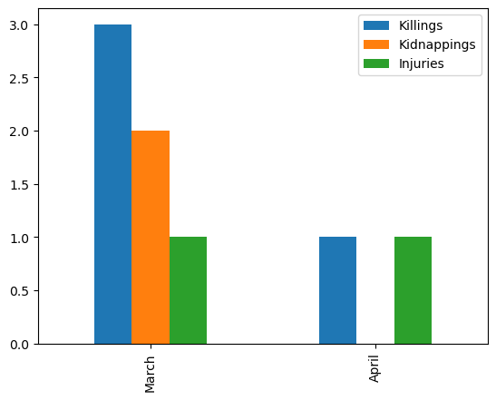

```python
# Creating a bar plot for all of the different incidents for March 2019 and April 2019:
March_April.plot.bar()
```

-Based off the plot above, we can see that crime was worse in March 2019 than April 2019

```python
data_2
```

|  | Incident month | State/Province/Division/Governorate/Department | Total health worker killed | Total health worker kidnapped | Total health worker injured |
| --- | --- | --- | --- | --- | --- |
| 13 | 2 | Khyber Pakhtunkhwa province | 0 | 0 | 0 |
| 17 | 3 | Punjab province | 0 | 2 | 0 |
| 15 | 3 | Khyber Pakhtunkhwa province | 1 | 0 | 1 |
| 18 | 3 | Punjab province | 1 | 0 | 1 |
| 19 | 3 | Khyber Pakhtunkhwa province | 0 | 0 | 0 |
| 16 | 3 | Punjab province | 1 | 0 | 1 |
| 1 | 4 | Balochistan province | 1 | 0 | 1 |
| 5 | 4 | Khyber Pakhtunkhwa province | 0 | 0 | 0 |
| 4 | 4 | Punjab province | 0 | 0 | 0 |
| 3 | 4 | Punjab province | 0 | 0 | 0 |
| 2 | 4 | Khyber Pakhtunkhwa province | 0 | 0 | 0 |
| 20 | 5 | Khyber Pakhtunkhwa province | 0 | 0 | 0 |
| 21 | 5 | Punjab province | 1 | 0 | 1 |
| 8 | 7 | Khyber Pakhtunkhwa province | 2 | 0 | 2 |
| 14 | 7 | Balochistan province | 0 | 0 | 0 |
| 7 | 7 | Khyber Pakhtunkhwa province | 0 | 0 | 0 |
| 6 | 8 | Sindh province | 0 | 0 | 0 |
| 23 | 9 | Khyber Pakhtunkhwa province | 0 | 0 | 0 |
| 10 | 9 | Khyber Pakhtunkhwa province | 0 | 1 | 0 |
| 9 | 9 | Khyber Pakhtunkhwa province | 0 | 1 | 0 |
| 22 | 11 | Punjab province | 0 | 0 | 0 |
| 11 | 12 | Khyber Pakhtunkhwa province | 0 | 0 | 0 |
| 12 | 12 | Khyber Pakhtunkhwa province | 0 | 0 | 0 |

```python
# Using the value_counts method to count up how often each Province in the Province column appears in the 2019 DataFrame:
province_counts = data_2['State/Province/Division/Governorate/Department'].value_counts().sort_index()
```

```
([0, 1, 2, 3],
 [Text(0, 0, 'Balochistan province'),
```

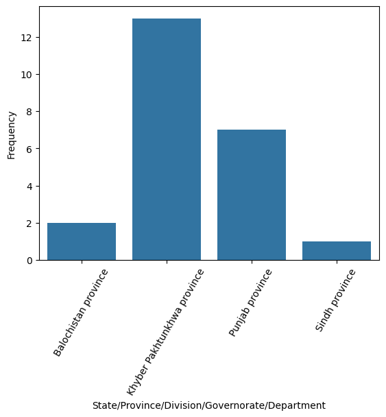

```python
# Making a bar plot for the short frequency table of the Provinces:
sns.barplot(x=province_counts.index, y=province_counts.to_numpy())
plt.ylabel('Frequency')
plt.xticks(rotation = 60)
```

- We can see that the Khyber Pakhtunkhwa Province had the most crime.

In conclusion, we can see that there were a lot of crimes within the healthcare system in Pakistan. However, it is important to point out that there were severaly missing values in both of the data frames. The data frames also get updated so chances are our results from this project can change. It is important to pick columns that do not have many missing values because if we choose columns that had missing values then we cannot jump to conclusions because we have no idea what the value of our missing values are.